| Saada |
| --- |

# Introduction

In this project, you will explore the question of whether college education causally affects political participation. Specifically, you will use replication data from by former Berkeley PhD students John Henderson and Sara Chatfield. Their paper is itself a replication study of by Cindy Kam and Carl Palmer. In their original 2008 study, Kam and Palmer argue that college education has no effect on later political participation, and use the propensity score matching to show that pre-college political activity drives selection into college and later political participation. Henderson and Chatfield in their 2011 paper argue that the use of the propensity score matching in this context is inappropriate because of the bias that arises from small changes in the choice of variables used to model the propensity score. They use (at that point a new method), which uses an approach similar to optimal matching to optimize Mahalanobis distance weights. Even with genetic matching, they find that balance remains elusive however, thus leaving open the question of whether education causes political participation.

You will use these data and debates to investigate the benefits and pitfalls associated with matching methods. Replication code for these papers is available online, but as you’ll see, a lot has changed in the last decade or so of data science! Throughout the assignment, use tools we introduced in lab from the and the packages. Specifically, try to use dplyr, tidyr, purrr, stringr, and ggplot instead of base R functions. While there are other matching software libraries available, MatchIt tends to be the most up to date and allows for consistent syntax.

# Data

The data is drawn from the which asked students and parents a variety of questions about their political participation. This survey was conducted in several waves. The first wave was in 1965 and established the baseline pre-treatment covariates. The treatment is whether the student attended college between 1965 and 1973 (the time when the next survey wave was administered). The outcome is an index that calculates the number of political activities the student engaged in after 1965. Specifically, the key variables in this study are:

Otherwise, we also have covariates measured for survey responses to various questions about political attitudes. We have covariates measured for the students in the baseline year, covariates for their parents in the baseline year, and covariates from follow-up surveys. . In general, post-treatment covariates will be clear from the name (i.e. student_1973Married indicates whether the student was married in the 1973 survey). Be mindful that the baseline covariates were all measured in 1965, the treatment occurred between 1965 and 1973, and the outcomes are from 1973 and beyond. We will distribute the Appendix from Henderson and Chatfield that describes the covariates they used, but please reach out with any questions if you have questions about what a particular variable means.

```r
install.packages("ggplotify", repos = "https://cloud.r-project.org")
options(repos = c(CRAN = "https://cloud.r-project.org"))
```

```r
# Load tidyverse and MatchIt
# Feel free to load other libraries as you wish
library(tidyverse)
library(cobalt)
library(MatchIt)
# Load ypsps data
ypsps <- read_csv('data/ypsps.csv')
head(ypsps)
```

```
## # A tibble: 6 × 174
##   interviewid college student_vote student_meeting student_other student_button
##         <dbl>   <dbl>        <dbl>           <dbl>         <dbl>          <dbl>
## 1           1       1            1               0             0              0
## 2           2       1            1               1             1              1
## 3           3       1            1               0             0              1
## 4           4       0            0               0             0              0
## 5           5       1            1               1             0              0
## 6           6       1            1               0             0              0
## # ℹ 168 more variables: student_money <dbl>, student_communicate <dbl>,
## #   student_demonstrate <dbl>, student_community <dbl>, student_ppnscal <dbl>,
## #   student_PubAff <dbl>, student_Newspaper <dbl>, student_Radio <dbl>,
## #   student_TV <dbl>, student_Magazine <dbl>, student_FamTalk <dbl>,
## #   student_FrTalk <dbl>, student_AdultTalk <dbl>, student_PID <dbl>,
## #   student_SPID <dbl>, student_GovtOpinion <dbl>, student_GovtCrook <dbl>,
## #   student_GovtWaste <dbl>, student_TrGovt <dbl>, student_GovtSmart <dbl>, …
```

# Randomization

Matching is usually used in observational studies to to approximate random assignment to treatment. But could it be useful even in randomized studies? To explore the question do the following:

```r
# Generate a vector that randomly assigns each unit to treatment/control
set.seed(224)
ypsps <- ypsps %>%
  mutate(treatment = sample(c(0, 1), size = nrow(ypsps), replace = TRUE))
```

```r
# Choose a baseline covariate (use dplyr for this)
#   I am choosing "student_money"
baseline_cov <- ypsps %>%
  select(student_money)
```

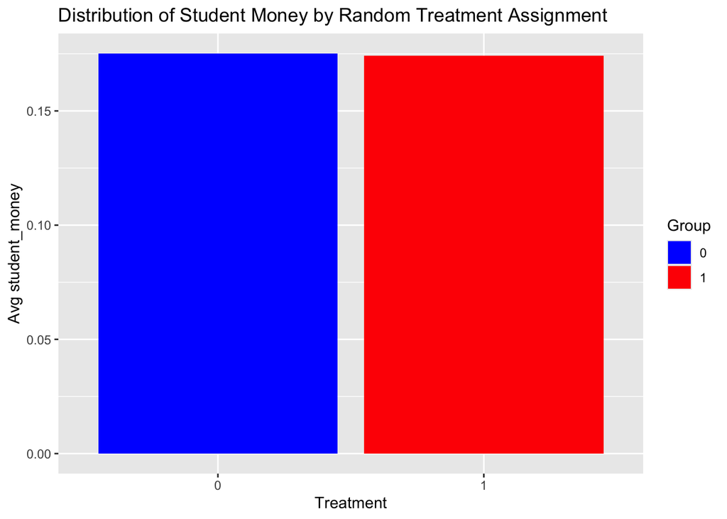

```r
# Visualize the distribution by treatment/control (ggplot)
ypsps %>%
  group_by(treatment) %>%
  summarise(avg_student_money = mean(student_money)) %>%
  ggplot(aes(x = factor(treatment), y = avg_student_money, fill = factor(treatment))) +
  geom_col() +
  labs(title = "Distribution of Student Money by Random Treatment Assignment",
       x = "Treatment",
       y = "Avg student_money",
       fill = "Group") +
  scale_fill_manual(values = c("0" = "blue", "1" = "red"))
```

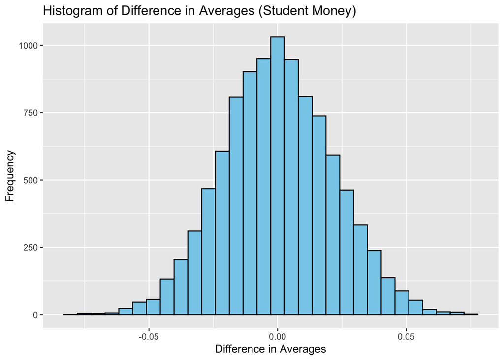

```r
# Simulate this 10,000 times (monte carlo simulation - see R Refresher for a hint)
diffs <- numeric(10000) # empty array

# perform 10,000 simulations
for(i in 1:10000) {
  treatment <- sample(c(0, 1), size = nrow(ypsps), replace = TRUE)
  # updating treatment column
  ypsps$treatment = treatment
  # difference in average student_money between treatment groups
  diff_in_averages = ypsps %>%
    group_by(treatment) %>%
    summarise(avg = mean(student_money)) %>%
    summarise(diff = diff(avg)) %>%
    pull(diff)
  #print(diff_in_averages)
  diffs[i] = diff_in_averages
}

diffs_df = data.frame(diffs)


# Create a histogram of the differences
ggplot(diffs_df, aes(x = diffs)) +
  geom_histogram(bins = 30, fill = "skyblue", color = "black") +
  labs(title = "Histogram of Difference in Averages (Student Money)",
       x = "Difference in Averages",
       y = "Frequency")
```

## Questions

Your Answer: The average value of student_money is approximately 0.2 for both treatment (1) and control (0) groups This suggests that the random assignment is working as intended, on average, both groups have similar baseline characteristics. A balanced distribution like this might indicate that there isn’t any systematic difference between the treatment and control groups in terms of student donation to a campaign. The histogram of the differences, generated after 10,000 simulations, is concentrated around zero with a spread of values between 0 and 0.05 and between 0 and -0.05. This pattern shows that while the overall balance is achieved with average difference near zero, random chance can produce minor fluctuations in any individual simulation.

# Propensity Score Matching

## One Model

Select covariates that you think best represent the “true” model predicting whether a student chooses to attend college, and estimate a propensity score model to calculate the Average Treatment Effect on the Treated (ATT). Plot the balance of the top 10 (or fewer if you select fewer covariates). Report the balance of the p-scores across both the treatment and control groups, and using a threshold of standardized mean difference of p-score $\leq .1$, report the number of covariates that meet that balance threshold.

```r
# Select covariates that represent the "true" model for selection, fit model
glm_model <- glm(college ~ student_vote + student_meeting + student_money + student_FamTalk + student_Hobby + student_GPA + student_Knowledge + student_community + student_TV, data = ypsps, family = binomial)

ps_model <- matchit(college ~ student_vote + student_meeting + student_money + student_FamTalk + student_Hobby + student_GPA + student_Knowledge + student_community + student_TV, data = ypsps, method = "nearest", distance = "logit")
summary_ps_model <- summary(ps_model, standardize = TRUE)
print(summary_ps_model)
```

```
##
## Call:
## matchit(formula = college ~ student_vote + student_meeting +
##     student_money + student_FamTalk + student_Hobby + student_GPA +
##     student_Knowledge + student_community + student_TV, data = ypsps,
##     method = "nearest", distance = "logit")
##
## Summary of Balance for All Data:
##                   Means Treated Means Control Std. Mean Diff. Var. Ratio
## distance                 0.7306        0.4796          1.2714     0.7634
## student_vote             0.8070        0.5721          0.5952          .
## student_meeting          0.2989        0.0909          0.4543          .
## student_money            0.2192        0.0953          0.2993          .
## student_FamTalk          1.8431        2.1131         -0.2932     0.7770
## student_Hobby            1.3873        1.3747          0.0143     1.0345
## student_GPA              2.2740        2.6231         -0.5332     0.9101
## student_Knowledge        0.6752        0.4634          0.9300     0.9403
## student_community        0.3350        0.1774          0.3339          .
## student_TV               2.2167        2.1308          0.0672     0.9957
##                   eCDF Mean eCDF Max
## distance             0.2844   0.4755
## student_vote         0.2349   0.2349
## student_meeting      0.2080   0.2080
## student_money        0.1238   0.1238
## student_FamTalk      0.0675   0.1018
## student_Hobby        0.0059   0.0094
## student_GPA          0.0698   0.2328
## student_Knowledge    0.1815   0.3678
## student_community    0.1576   0.1576
## student_TV           0.0147   0.0452
##
## Summary of Balance for Matched Data:
##                   Means Treated Means Control Std. Mean Diff. Var. Ratio
## distance                 0.8739        0.4796          1.9971     0.0820
## student_vote             0.9180        0.5721          0.8764          .
## student_meeting          0.4678        0.0909          0.8234          .
## student_money            0.3215        0.0953          0.5467          .
## student_FamTalk          1.7317        2.1131         -0.4141     0.7014
## student_Hobby            1.4013        1.3747          0.0302     1.0613
## student_GPA              2.0931        2.6231         -0.8095     0.8970
## student_Knowledge        0.8023        0.4634          1.4883     0.5064
## student_community        0.4390        0.1774          0.5543          .
## student_TV               2.3437        2.1308          0.1667     1.0169
##                   eCDF Mean eCDF Max Std. Pair Dist.
## distance             0.4763   0.8426          1.9971
## student_vote         0.3459   0.3459          1.0899
## student_meeting      0.3769   0.3769          0.9009
## student_money        0.2262   0.2262          0.7825
## student_FamTalk      0.0953   0.1596          1.0979
## student_Hobby        0.0078   0.0177          0.7248
## student_GPA          0.1060   0.3481          1.1549
## student_Knowledge    0.2905   0.5898          1.5467
## student_community    0.2616   0.2616          0.8550
## student_TV           0.0355   0.0953          1.0451
##
## Sample Sizes:
##           Control Treated
## All           451     803
## Matched       451     451
## Unmatched       0     352
## Discarded       0       0
```

```r
# Plot the balance for the top 10 covariates
cov_means = ypsps %>% group_by(treatment) %>% summarise(
  avg_student_money = mean(student_money),
  avg_student_vote  = mean(student_vote),
  avg_student_meeting = mean(student_meeting),
  avg_student_FamTalk = mean(student_FamTalk),
  avg_student_Hobby = mean(student_Hobby),
  avg_student_GPA = mean(student_GPA),
  avg_student_Knowledge = mean(student_Knowledge),
  avg_student_community = mean(student_community),
  avg_student_TV = mean(student_TV)
  )

print(cov_means)
```

```
## # A tibble: 2 × 10
##   treatment avg_student_money avg_student_vote avg_student_meeting
##       <dbl>             <dbl>            <dbl>               <dbl>
## 1         0             0.177            0.690               0.210
## 2         1             0.172            0.753               0.238
## # ℹ 6 more variables: avg_student_FamTalk <dbl>, avg_student_Hobby <dbl>,
## #   avg_student_GPA <dbl>, avg_student_Knowledge <dbl>,
## #   avg_student_community <dbl>, avg_student_TV <dbl>
```

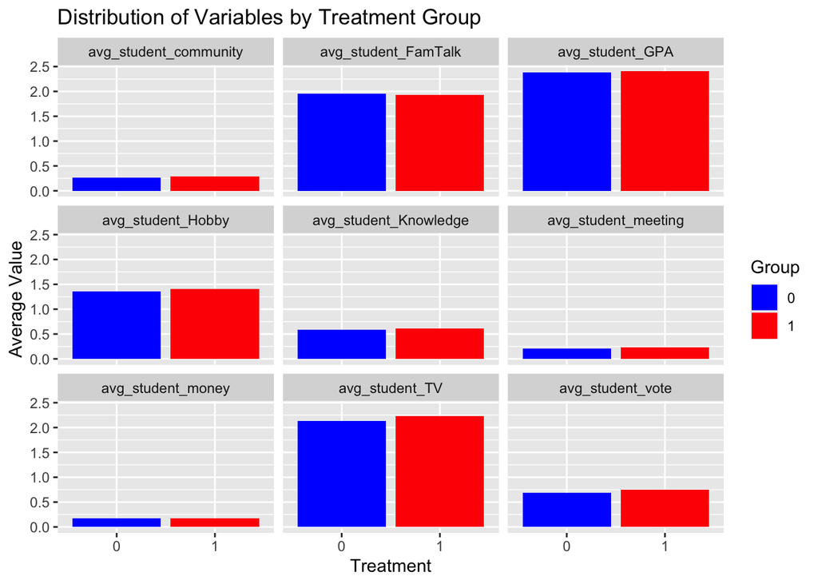

```r
cov_means %>%  pivot_longer(
    cols = -treatment,       # all columns except treatment
    names_to = "variable",   # name for the new column holding variable names
    values_to = "avg_value"  # name for the new column holding average values
  ) %>%
  ggplot(aes(x = factor(treatment), y = avg_value, fill = factor(treatment))) +
  geom_col() +
  facet_wrap(~ variable) +
  labs(title = "Distribution of Variables by Treatment Group",
       x = "Treatment",
       y = "Average Value",
       fill = "Group") +
  scale_fill_manual(values = c("0" = "blue", "1" = "red"))
```

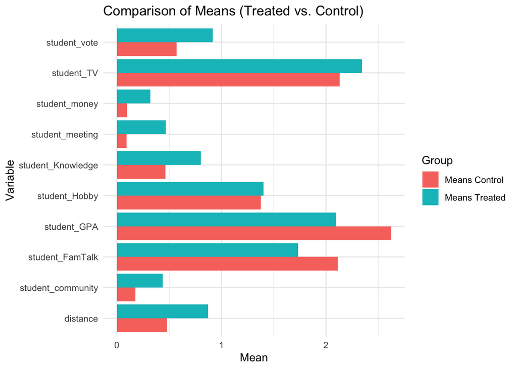

```r
# plot from the matched dataset
result_df <- as.data.frame(summary_ps_model$sum.matched)
result_df$variable <- rownames(result_df)
rownames(result_df) <- NULL

result_df_long <- result_df %>%
  select(variable, `Means Treated`, `Means Control`) %>%
  pivot_longer(
    cols = c("Means Treated", "Means Control"),
    names_to = "Group",
    values_to = "MeanValue"
  )

ggplot(result_df_long, aes(x = variable, y = MeanValue, fill = Group)) +
  geom_col(position = position_dodge()) +
  labs(
    title = "Comparison of Means (Treated vs. Control)",
    x = "Variable",
    y = "Mean"
  ) +
  theme_minimal() +
  coord_flip()
```

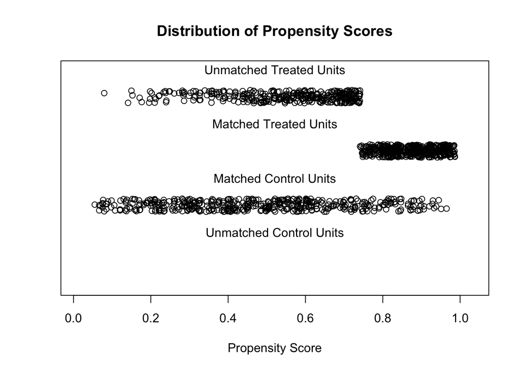

```r
# Report the overall balance and the proportion of covariates that meet the balance threshold
plot(ps_model, type = "jitter", interactive = FALSE)
```

```r
# balance of scores (mean):
matched_data = match.data(ps_model)

# get balance of score by group
matched_data %>%
  group_by(treatment) %>%
  summarise(
    mean_distance = mean(distance, na.rm = TRUE),
    mean_distance_weighted = weighted.mean(distance, w = weights, na.rm = TRUE),
    sd_distance   = sd(distance, na.rm = TRUE)
  )
```

```
## # A tibble: 2 × 4
##   treatment mean_distance mean_distance_weighted sd_distance
##       <dbl>         <dbl>                  <dbl>       <dbl>
## 1         0         0.663                  0.663       0.265
## 2         1         0.690                  0.690       0.251
```

## Simulations

Henderson/Chatfield argue that an improperly specified propensity score model can actually the bias of the estimate. To demonstrate this, they simulate 800,000 different propensity score models by choosing different permutations of covariates. To investigate their claim, do the following:

```r
# Remove post-treatment covariates
ypsps_pre <- ypsps %>% select(-matches("1973"))
```

```r
# Randomly select features
candidate_covs <- c("student_vote", "student_meeting", "student_money",
                    "student_FamTalk", "student_Hobby", "student_GPA",
                    "student_Knowledge", "student_community", "student_TV")
```

```r
# Simulate random selection of features 10k+ times
# 10k simulations taking too long, switched to 1,000 which also took too long
# running 100 simulations
nsim <- 1000
sim_results <- data.frame(sim = 1:nsim,
                          att = NA,
                          prop_balanced = NA,
                          mean_improv = NA,
                          covariates = NA,
                          stringsAsFactors = FALSE)

# Create a list to store the matching models
model_list <- vector("list", nsim)
```

```r
# Fit p-score models and save ATTs, proportion of balanced covariates, and mean percent balance improvement
for(i in 1:nsim){
  n_cov <- sample(1:length(candidate_covs), 1)
  selected_covs <- sample(candidate_covs, n_cov)
  formula_i <- as.formula(paste("college ~", paste(selected_covs, collapse = " + ")))
  ps_mod <- matchit(formula_i, data = ypsps_pre, method = "nearest", distance = "logit")
  model_list[[i]] <- ps_mod
  matched_dat <- match.data(ps_mod)
  att_est <- with(matched_dat, mean(student_ppnscal[college == 1]) - mean(student_ppnscal[college == 0]))
  sum_balance <- summary(ps_mod, standardize = TRUE)
  unmatched_smd <- sum_balance$sum.all[selected_covs, "Std. Mean Diff."]
  matched_smd <- sum_balance$sum.matched[selected_covs, "Std. Mean Diff."]
  prop_bal <- mean(abs(matched_smd) <= 0.1)
  improv <- ifelse(abs(unmatched_smd) > 0,
                   (abs(unmatched_smd) - abs(matched_smd)) / abs(unmatched_smd) * 100,
                   NA)
  mean_improv <- mean(improv, na.rm = TRUE)
  sim_results$att[i] <- att_est
  sim_results$prop_balanced[i] <- prop_bal
  sim_results$mean_improv[i] <- mean_improv
  sim_results$covariates[i] <- paste(selected_covs, collapse = ", ")
}
```

[output not shown]

[output cut: 1945 more lines]

[output not shown]

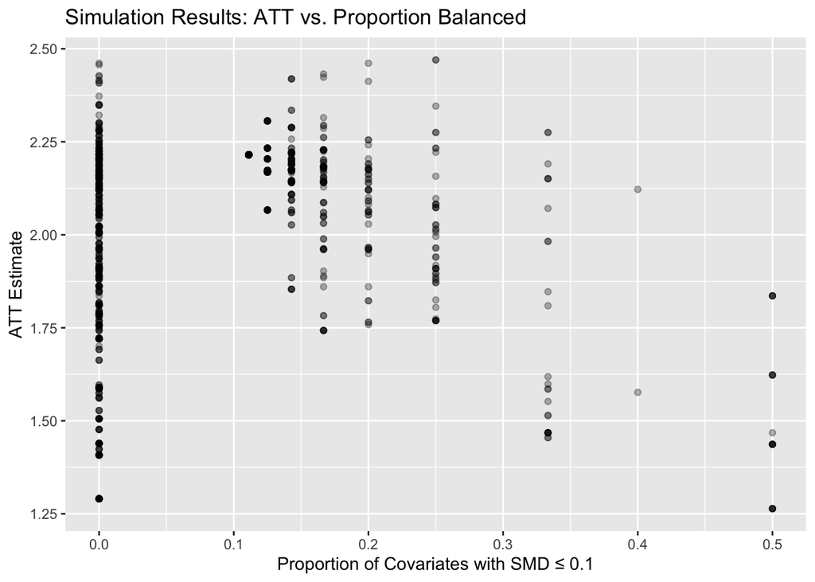

```r
# Plot ATT v. proportion
ggplot(sim_results, aes(x = prop_balanced, y = att)) +
  geom_point(alpha = 0.3) +
  labs(title = "Simulation Results: ATT vs. Proportion Balanced",
       x = "Proportion of Covariates with SMD ≤ 0.1",
       y = "ATT Estimate")
```

```r
att_summary <- summary(sim_results$att)
print(att_summary)
```

```
##    Min. 1st Qu.  Median    Mean 3rd Qu.    Max.
##   1.264   1.860   2.122   2.007   2.215   2.470
```

```r
att_sd <- sd(sim_results$att, na.rm = TRUE)
att_quantiles <- quantile(sim_results$att, probs = c(0.05, 0.5, 0.95), na.rm = TRUE)

cat("Standard Deviation:", att_sd, "\n")
```

```
## Standard Deviation: 0.2697149
```

```r
print(att_quantiles)
```

```
##       5%      50%      95%
## 1.436807 2.121951 2.288248
```

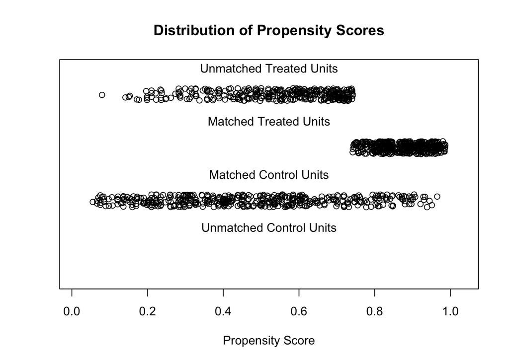

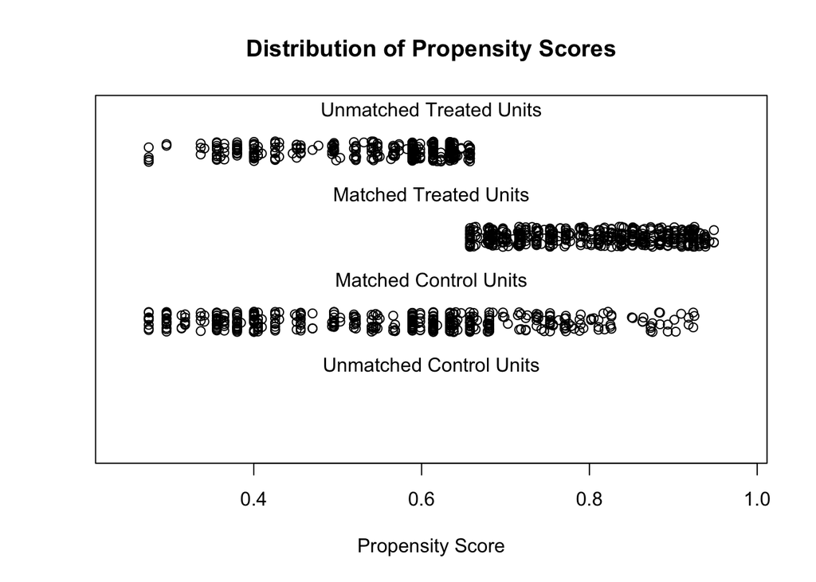

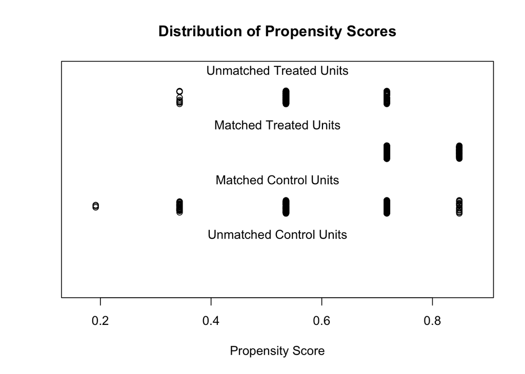

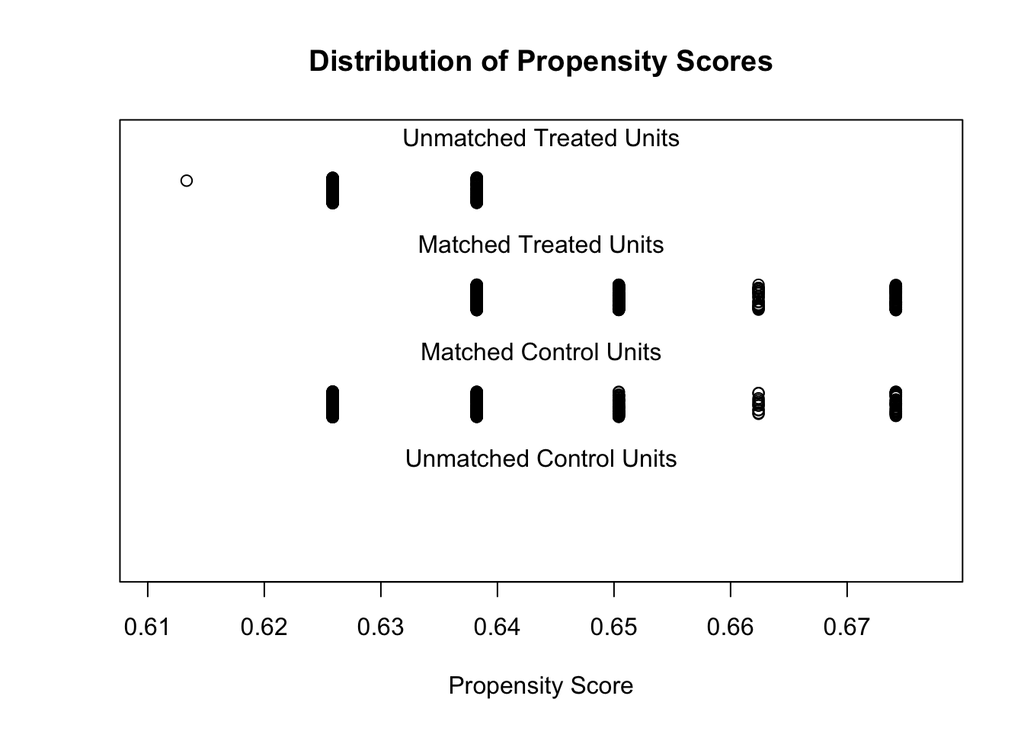

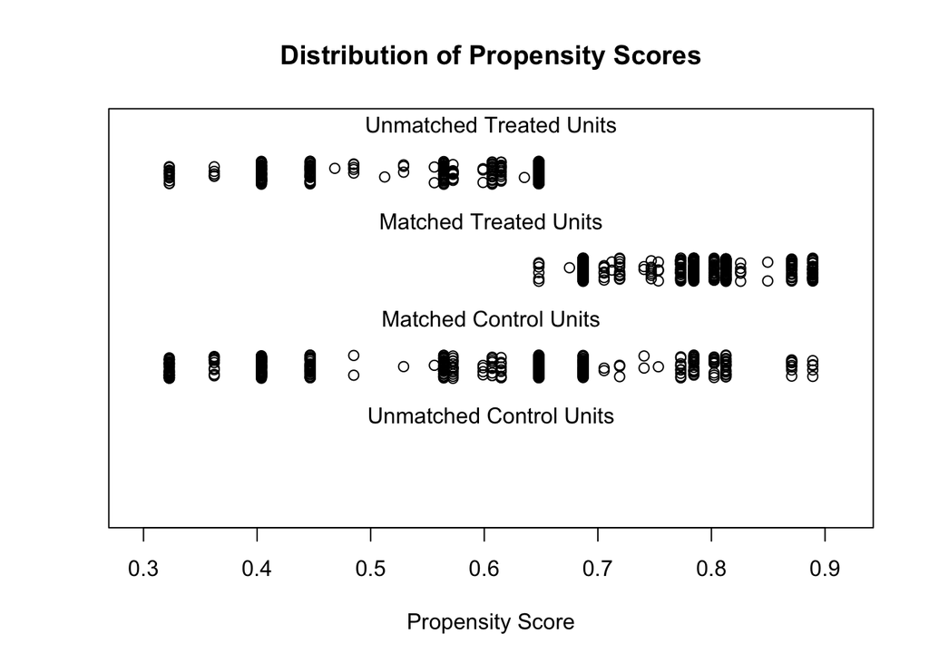

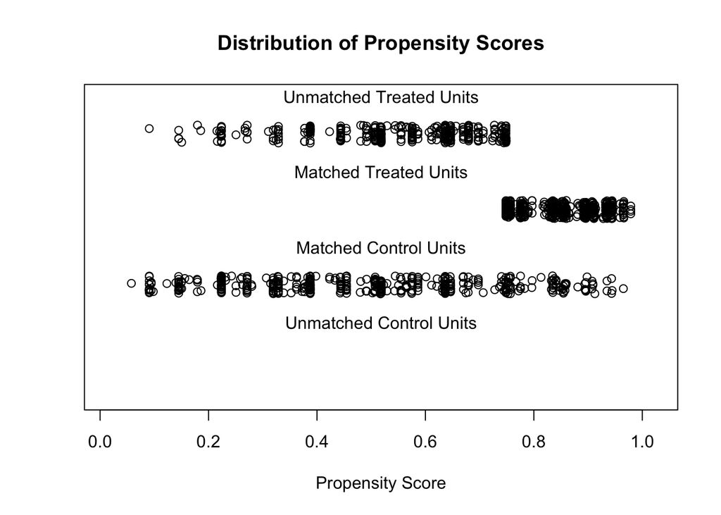

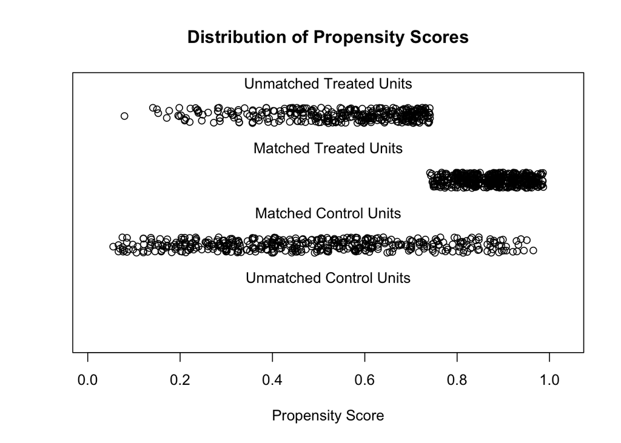

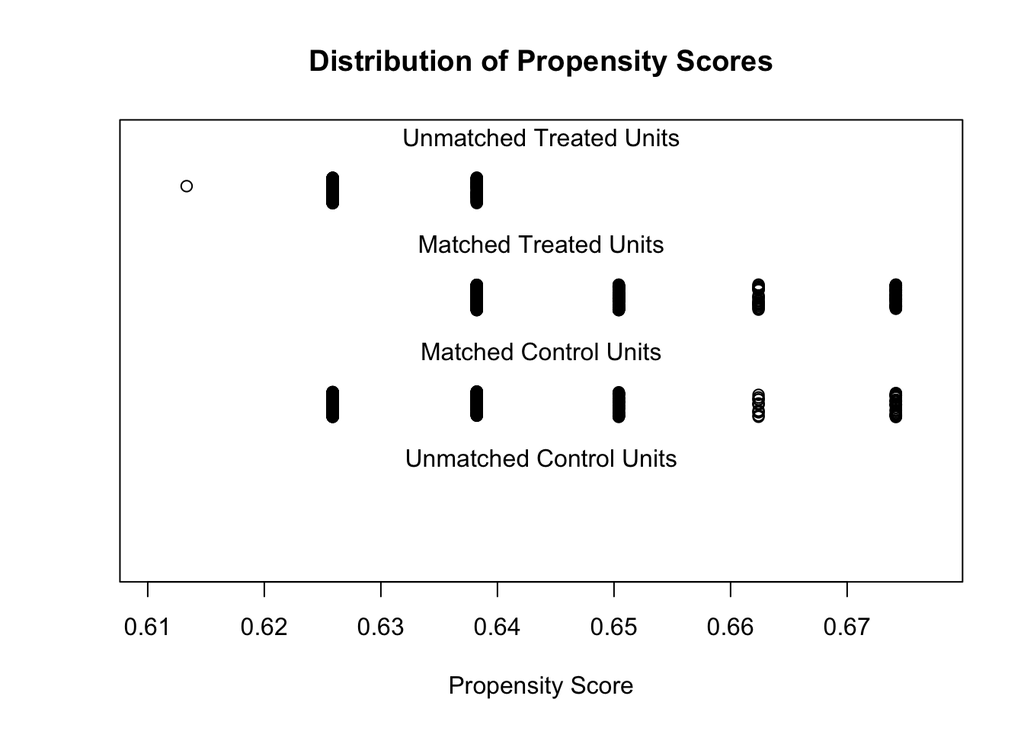

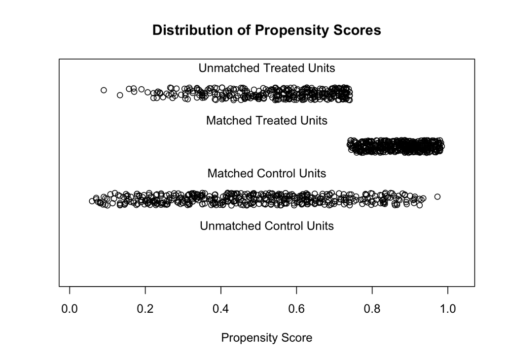

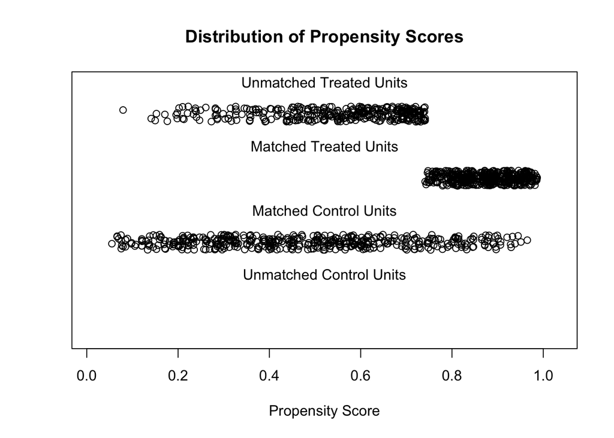

```r
# 10 random covariate balance plots (hint try gridExtra)
library(gridExtra)
library(gridGraphics)
set.seed(456)
sample_indices <- sample(1:nsim, 10)
balance_plots <- list()
for (idx in sample_indices) {
 captured_plot <-
      plot(model_list[[idx]], type = "jitter", interactive = FALSE)

  balance_plots[[length(balance_plots) + 1]] = captured_plot
}
```

```r
#print(length(balance_plots))
#grid.arrange(grobs = balance_plots, ncol = 2)

# Note: ggplot objects are finnicky so ask for help if you're struggling to automatically create them; consider using functions!
```

# Matching Algorithm of Your Choice

## Simulate Alternative Model

Henderson/Chatfield propose using genetic matching to learn the best weights for Mahalanobis distance matching. Choose a matching algorithm other than the propensity score (you may use genetic matching if you wish, but it is also fine to use the greedy or optimal algorithms we covered in lab instead). Repeat the same steps as specified in Section 4.2 and answer the following questions:

```r
# Remove post-treatment covariates
ypsps_pre <- ypsps %>% select(-matches("1973"))
```

```r
# Randomly select features
candidate_covs <- c("student_vote", "student_meeting", "student_money",
                    "student_FamTalk", "student_Hobby", "student_GPA",
                    "student_Knowledge", "student_community", "student_TV")
```

```r
# simulate random selection of features 10,000 times
# pivoted to 100 since 10k took hours and still didn't finish running
nsim_alt <- 100
sim_results_alt <- data.frame(sim = 1:nsim_alt,
                              att = NA,
                              prop_balanced = NA,
                              mean_improv = NA,
                              covariates = NA,
                              stringsAsFactors = FALSE)
```

```r
# Fit  models and save ATTs, proportion of balanced covariates, and mean percent balance improvement

# list to store the matching models for Mahalanobis method
model_list_alt <- vector("list", nsim_alt)

for(i in 1:nsim_alt){

  # randomly decide how many covariates to include
  n_cov <- sample(1:length(candidate_covs), 1)

  # randomly select 'n_cov' covariates from the candidate list
  selected_covs <- sample(candidate_covs, n_cov)

  # create the model formula using 'college' as the treatment indicator
  formula_i <- as.formula(paste("college ~", paste(selected_covs, collapse = " + ")))

  # fit the alternative matching model using optimal matching with Mahalanobis distance
  alt_mod <- matchit(formula_i, data = ypsps_pre, method = "optimal", distance = "mahalanobis")

  # save the matching model
  model_list_alt[[i]] <- alt_mod

  # extract the matched data (including weights and computed distances)
  matched_dat <- match.data(alt_mod)

  # compute the ATT using the outcome variable "student_ppnscal"
  att_est <- with(matched_dat, mean(student_ppnscal[college == 1]) - mean(student_ppnscal[college == 0]))

  # balance summary with standardization
  sum_balance <- summary(alt_mod, standardize = TRUE)

  # extract unmatched and matched SMDs for the selected covariates
  unmatched_smd <- sum_balance$sum.all[selected_covs, "Std. Mean Diff."]
  matched_smd   <- sum_balance$sum.matched[selected_covs, "Std. Mean Diff."]

  # calculate the proportion of selected covariates with an absolute SMD ≤ 0.1 after matching
  prop_bal <- mean(abs(matched_smd) <= 0.1)

  # calculate the percent improvement in balance for each selected covariate
  improv <- ifelse(abs(unmatched_smd) > 0,
                   (abs(unmatched_smd) - abs(matched_smd)) / abs(unmatched_smd) * 100,
                   NA)
  mean_improv <- mean(improv, na.rm = TRUE)

  # Save the outputs in the simulation results data frame
  sim_results_alt$att[i] <- att_est
  sim_results_alt$prop_balanced[i] <- prop_bal
  sim_results_alt$mean_improv[i] <- mean_improv
  sim_results_alt$covariates[i] <- paste(selected_covs, collapse = ", ")
}
```

[output not shown]

[output cut: 145 more lines]

[output not shown]

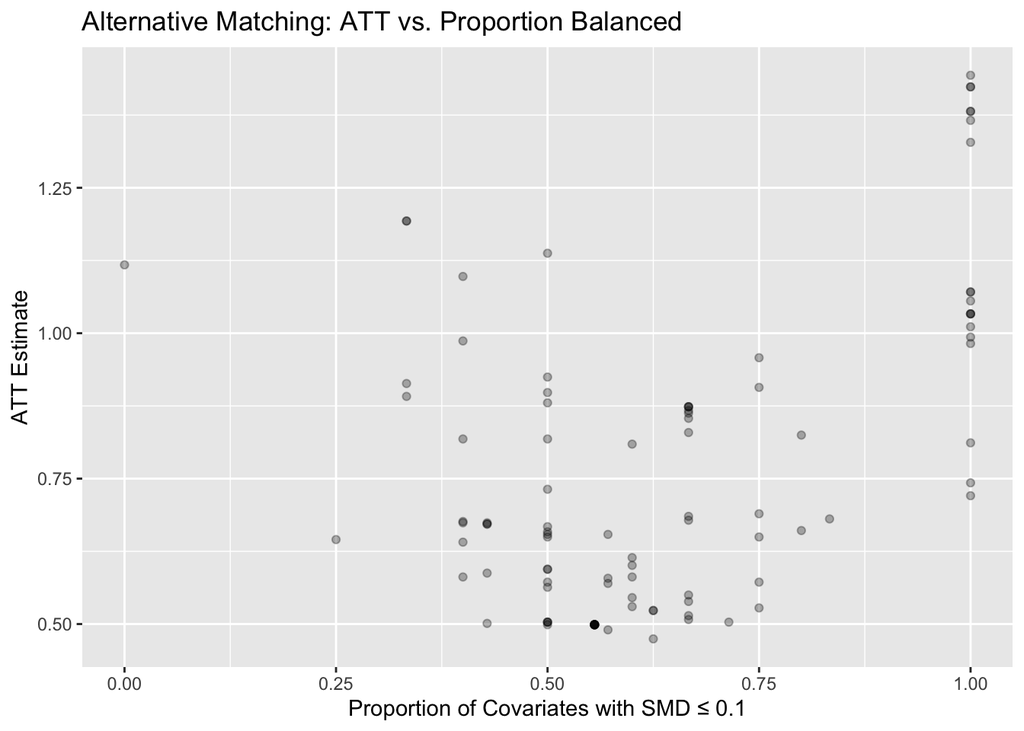

```r
# Plot ATT v. proportion
ggplot(sim_results_alt, aes(x = prop_balanced, y = att)) +
  geom_point(alpha = 0.3) +
  labs(title = "Alternative Matching: ATT vs. Proportion Balanced",
       x = "Proportion of Covariates with SMD ≤ 0.1",
       y = "ATT Estimate")
```

```r
#love.plot(model_list_alt[[1]],
 #         stats = "mean.diffs",
  #        threshold = 0.1,
   #       var.order = "unadjusted",
    #      stars = "none",
     #     title = "Test Love Plot")
```

[figure not shown]

```r
# 10 random covariate balance plots (hint try gridExtra)
#library(gridExtra)
#library(gridGraphics)
#library(grid)
#library(cobalt)
install.packages("ggplotify")
library(ggplotify)

set.seed(789)
sample_indices <- sample(1:nsim_alt, 10)
# I'm honestly not sure what I'm doing at this point, I've tried everything and this won't work
# convert each love plot to a grob using as.grob()
love_plots <- lapply(sample_indices, function(idx) {
  as.grob(
    love.plot(model_list_alt[[idx]],
              stats = "mean.diffs",
              threshold = 0.1,
              var.order = "unadjusted",
              stars = "none",
              title = paste("Love Plot for Simulation", idx))
  )
})
grid.arrange(grobs = love_plots, ncol = 2)
```

```r
# Note: ggplot objects are finnicky so ask for help if you're struggling to automatically create them; consider using functions!
```

```r
#model_list_alt[[1]]
```

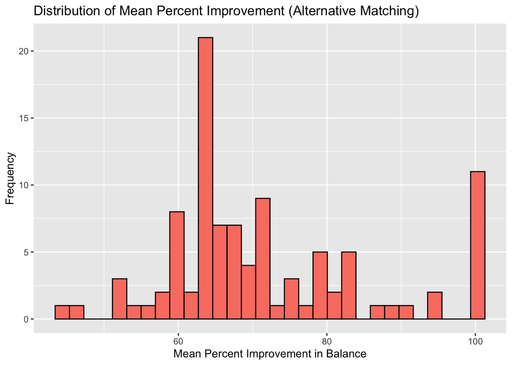

```r
# Visualization for distributions of percent improvement
ggplot(sim_results_alt, aes(x = mean_improv)) +
  geom_histogram(bins = 30, fill = "salmon", color = "black") +
  labs(title = "Distribution of Mean Percent Improvement (Alternative Matching)",
       x = "Mean Percent Improvement in Balance",
       y = "Frequency")
```

```r
att_summary <- summary(sim_results_alt$att)
cat("ATT Summary:\n")
```

```
## ATT Summary:
```

```r
print(att_summary)
```

```
##    Min. 1st Qu.  Median    Mean 3rd Qu.    Max.
##  0.4745  0.5488  0.6741  0.7666  0.9085  1.4435
```

```r
prop_bal_summary <- summary(sim_results_alt$prop_balanced)
cat("\nProportion Balanced Summary:\n")
```

```
##
## Proportion Balanced Summary:
```

```r
print(prop_bal_summary)
```

```
##    Min. 1st Qu.  Median    Mean 3rd Qu.    Max.
##   0.000   0.500   0.600   0.636   0.750   1.000
```

```r
median_bal <- median(sim_results_alt$prop_balanced, na.rm = TRUE)
num_higher <- sum(sim_results_alt$prop_balanced > median_bal, na.rm = TRUE)
cat("\nNumber of simulations with proportion balanced above median:", num_higher, "\n")
```

```
##
## Number of simulations with proportion balanced above median: 45
```

```r
cat("Proportion of simulations with high balance:", num_higher / nrow(sim_results_alt), "\n")
```

```
## Proportion of simulations with high balance: 0.45
```

```r
improv_summary <- summary(sim_results_alt$mean_improv)
cat("\nMean Percent Improvement Summary:\n")
```

```
##
## Mean Percent Improvement Summary:
```

```r
print(improv_summary)
```

```
##    Min. 1st Qu.  Median    Mean 3rd Qu.    Max.
##   44.05   62.94   67.51   71.55   78.71  100.00
```

## Questions

Looking ahead to the discussion questions, you may choose to model the propensity score using an algorithm other than logistic regression and perform these simulations again, if you wish to explore the second discussion question further.